# Babynames Exercise

Data Visualization - Columbia University

Yifei Dong

## Install data package

We are using the package “babynames” to get familiar with time series plots.

```r
library(babynames)
```

And while we are at it, let’s load a few more necessary and helpful packages.

```r
library(ggplot2)    # the king of plotting
library(magrittr)   # chain operators, e.g. to "pipe" a value forward
library(tidyverse)      # for data manipulation
library(packcircles) # for circle packing
library(scales)
library(ggthemes) # for plot themes
```

## Let’s check the data

```r
str(babynames)
```

```
## tibble [1,924,665 × 5] (S3: tbl_df/tbl/data.frame)
##  $ year: num [1:1924665] 1880 1880 1880 1880 1880 1880 1880 1880 1880 1880 ...
##  $ sex : chr [1:1924665] "F" "F" "F" "F" ...
##  $ name: chr [1:1924665] "Mary" "Anna" "Emma" "Elizabeth" ...
##  $ n   : int [1:1924665] 7065 2604 2003 1939 1746 1578 1472 1414 1320 1288 ...
##  $ prop: num [1:1924665] 0.0724 0.0267 0.0205 0.0199 0.0179 ...
```

## From A…

```r
head(babynames)
```

```
## # A tibble: 6 x 5
##    year sex   name          n   prop
##   <dbl> <chr> <chr>     <int>  <dbl>
## 1  1880 F     Mary       7065 0.0724
## 2  1880 F     Anna       2604 0.0267
## 3  1880 F     Emma       2003 0.0205
## 4  1880 F     Elizabeth  1939 0.0199
## 5  1880 F     Minnie     1746 0.0179
## 6  1880 F     Margaret   1578 0.0162
```

## to … Z

```r
tail(babynames)
```

```
## # A tibble: 6 x 5
##    year sex   name       n       prop
##   <dbl> <chr> <chr>  <int>      <dbl>
## 1  2017 M     Zyhier     5 0.00000255
## 2  2017 M     Zykai      5 0.00000255
## 3  2017 M     Zykeem     5 0.00000255
## 4  2017 M     Zylin      5 0.00000255
## 5  2017 M     Zylis      5 0.00000255
## 6  2017 M     Zyrie      5 0.00000255
```

## How many names?

```r
# How many unique names?
length(unique(babynames$name))
```

```
## [1] 97310
```

```r
# How many kids in database (note n>5 per name/year)
sum(babynames$n)/10^6
```

```
## [1] 348.1205
```

## Plot a single name over time - Choose yours!

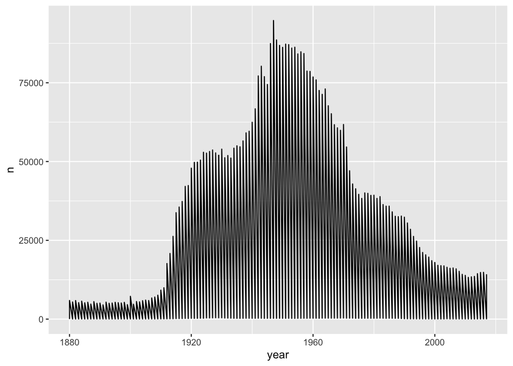

```r
ggplot(babynames, aes(year, n)) +
  geom_line(data = filter(babynames, name=="James"))
```

Want went wrong here?

## Check the data again

```r
head(filter(babynames, name=="James"))
```

```
## # A tibble: 6 x 5
##    year sex   name      n     prop
##   <dbl> <chr> <chr> <int>    <dbl>
## 1  1880 F     James    22 0.000225
## 2  1880 M     James  5927 0.0501
## 3  1881 F     James    24 0.000243
## 4  1881 M     James  5441 0.0502
## 5  1882 F     James    18 0.000156
## 6  1882 M     James  5892 0.0483
```

```r
  # -> There are female and male entries for some names.
```

## Plot a single name over time

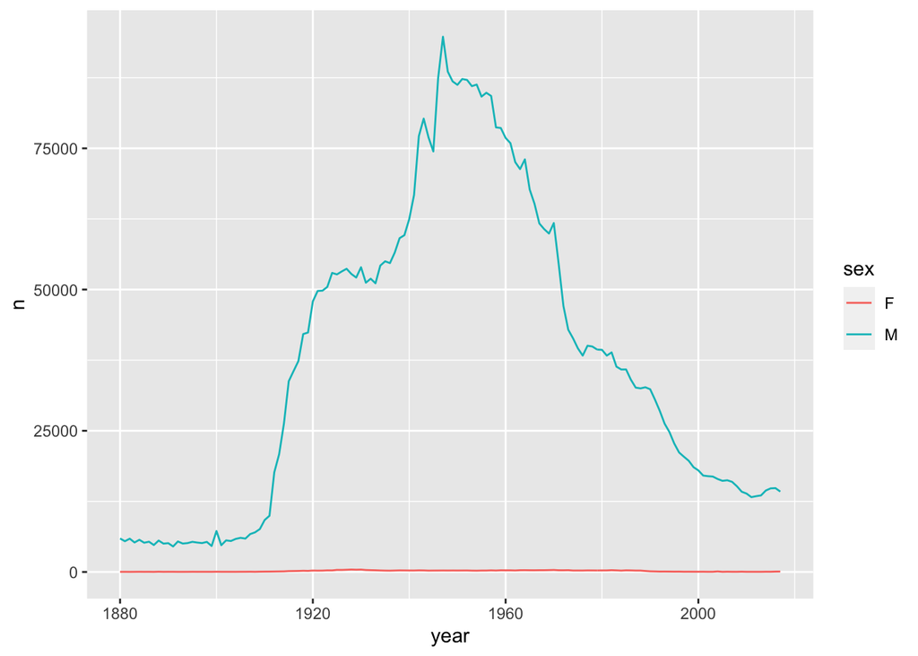

```r
ggplot(babynames, aes(year, n)) +
  geom_line(data = filter(babynames, name=="James"), aes(color = sex))
```

## Top 10 Names of all time

```r
library(magrittr)
  # this is for the chain operator %>%
  # also contained in the tidyverse package
```

- We select the top 10 boys and girls names of all time from the overall dataset

```r
# Try to follow this code chunk at home, using dplyr() and magrittr()
top10 <- babynames %>%
  group_by(sex, name) %>%
  summarize(total = sum(n)) %>%
  arrange(desc(total)) %>%
  group_by(sex) %>%
  mutate(rank=row_number()) %>%
  filter(rank<=10)  %>%
  arrange(sex, rank)
```

```r
# Similar methods
babynames %>%
  group_by(sex, name) %>%
  summarise(total = sum(n)) %>%
  arrange(sex, desc(total)) %>%
  group_by(sex) %>%
  top_n(10, wt = total) %>%
  mutate(rank = row_number())
```

```r
top10f <- top10 %>% filter(sex=="F")
top10m <- top10 %>% filter(sex=="M")
```

## Top 10 Names of all time - for girls

```
## # A tibble: 10 x 4
## # Groups:   sex [1]
##    sex   name        total  rank
##    <chr> <chr>       <int> <int>
##  1 F     Mary      4123200     1
##  2 F     Elizabeth 1629679     2
##  3 F     Patricia  1571692     3
##  4 F     Jennifer  1466281     4
##  5 F     Linda     1452249     5
##  6 F     Barbara   1434060     6
##  7 F     Margaret  1246649     7
##  8 F     Susan     1121440     8
##  9 F     Dorothy   1107096     9
## 10 F     Sarah     1073895    10
```

## Top 10 Names of all time - and boys

```
## # A tibble: 10 x 4
## # Groups:   sex [1]
##    sex   name      total  rank
##    <chr> <chr>     <int> <int>
##  1 M     James   5150472     1
##  2 M     John    5115466     2
##  3 M     Robert  4814815     3
##  4 M     Michael 4350824     4
##  5 M     William 4102604     5
##  6 M     David   3611329     6
##  7 M     Joseph  2603445     7
##  8 M     Richard 2563082     8
##  9 M     Charles 2386048     9
## 10 M     Thomas  2304948    10
```

## Plot most 10 common names for boys and girls

```r
babynames %>%
  filter(sex=="F") %>%
  filter(name %in% top10f$name) %>%
  ggplot(., aes(year, n)) +
  geom_line(aes(color=name, group=name))

babynames %>%
  filter(sex=="M") %>%
  filter(name %in% top10m$name) %>%
  ggplot(., aes(year, n)) +
  geom_line(aes(color=name, group=name))
```

## Plot 10 most common names

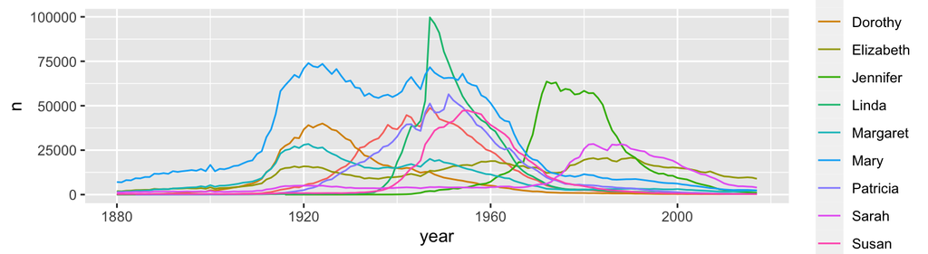

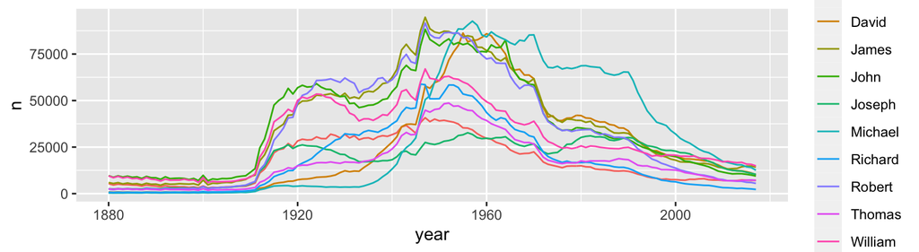

## Now on your own

1. Plot the most common names in 2017 over the entire period.

```r
exercise1 <- babynames %>%
  filter(year == 2017) %>%
  group_by(sex) %>%
  arrange(desc(n), .by_group = TRUE) %>%
  top_n(10, wt = n) %>%
  ungroup()
exercise1
```

```
## # A tibble: 20 x 5
##     year sex   name          n    prop
##    <dbl> <chr> <chr>     <int>   <dbl>
##  1  2017 F     Emma      19738 0.0105
##  2  2017 F     Olivia    18632 0.00994
##  3  2017 F     Ava       15902 0.00848
##  4  2017 F     Isabella  15100 0.00805
##  5  2017 F     Sophia    14831 0.00791
##  6  2017 F     Mia       13437 0.00717
##  7  2017 F     Charlotte 12893 0.00688
##  8  2017 F     Amelia    11800 0.00629
##  9  2017 F     Evelyn    10675 0.00569
## 10  2017 F     Abigail   10551 0.00563
## 11  2017 M     Liam      18728 0.00954
## 12  2017 M     Noah      18326 0.00933
## 13  2017 M     William   14904 0.00759
## 14  2017 M     James     14232 0.00725
## 15  2017 M     Logan     13974 0.00712
## 16  2017 M     Benjamin  13733 0.00699
## 17  2017 M     Mason     13502 0.00688
## 18  2017 M     Elijah    13268 0.00676
## 19  2017 M     Oliver    13141 0.00669
## 20  2017 M     Jacob     13106 0.00668
```

### Bar Chart

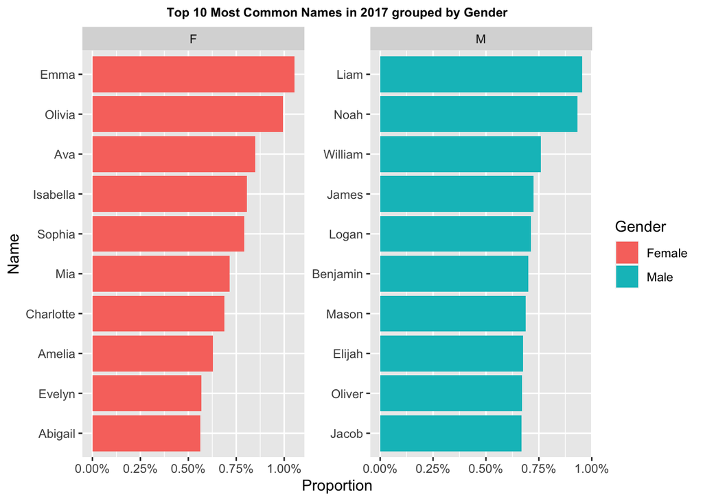

```r
# Use facet_warp when you have only one variable with many levels
ggplot(exercise1, aes(x = reorder(name, prop), y = prop, fill = sex))+
  geom_bar(stat = "identity")+
  facet_wrap(~sex, scales = "free")+ # by setting scales free, scales are vary across both rows and columns
  scale_fill_discrete("Gender", labels = c("Female", "Male"))+
  scale_x_discrete("Name")+
  scale_y_continuous("Proportion", labels = scales::percent)+
  ggtitle("Top 10 Most Common Names in 2017 grouped by Gender")+
  theme(plot.title = element_text(size = 9, face = "bold", hjust = 0.5))+
  coord_flip()
```

### Optional: Circle Packing Chart

What I am doing here is to draw a `circle packing` chart with only one level of hierarchy. You just represent each entity or individual of your dataset with a circle, its size depending on a provided value. You need `packcircles` package to draw a circle packing chart. Check more about [circle packing](https://www.r-graph-gallery.com/305-basic-circle-packing-with-one-level.html) at R Graph Gallery.

```r
# circleProgressiveLayout automatically creates a data frame with x and y centers for circles and radii, based on the values for the data you feed it.
packing <- circleProgressiveLayout(exercise1$n, sizetype = "area")

####add the centers and radii to the sample data
exercise1 <- add_column(exercise1, packing)

# Provides more points for ggplot to draw the perimeters of the circles
dat.gg<-circleLayoutVertices(packing, npoints=50)
```

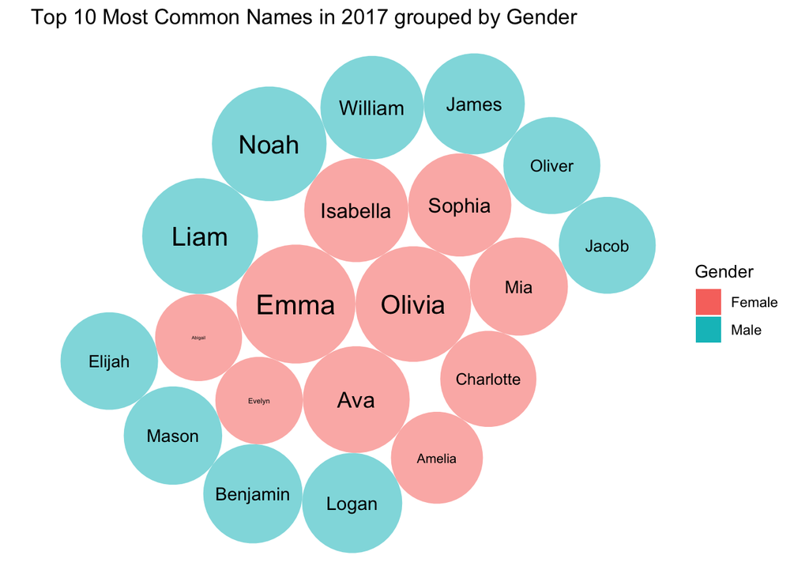

```r
ggplot()+
  geom_polygon(data=dat.gg,
               aes(x=x, ### this x value is the x-axis value of the center of the circles
                   y=y, ### this y value is the x-axis value of the center of the circles
                   group=id, #### this is the id number for the circles
                   fill=c(rep("blue", 510), rep("red", 510)), #### fill in the colors for the circles
                   alpha=0.6))+ ####adds some transparency to the colors
  geom_text(data = exercise1,
            aes(x = x,
                y = y,
                size = n, #### vary the size of the text based on relative magnitude of the variable of interest
                label = name), show.legend = FALSE)+
  labs(title = "Top 10 Most Common Names in 2017 grouped by Gender")+
  theme_void()+
  scale_fill_discrete("Gender", labels = c("Female", "Male"))+
  guides(alpha = FALSE)+
  coord_equal() ### makes your plot square
```

2. Explore which names are most often used as unisex names. For which names has the popularity over time changed a lot?

[output not shown]

[output not shown]

```r
unisex <- combined_dataset %>%
  filter(Female != "NA") %>%
  mutate(total_birth = Male+Female) %>%
  filter(total_birth >= 8000) %>%
  mutate(Mprop = Male/total_birth,
         Fprop = Female/total_birth) %>%
  mutate(difference = abs(Fprop-Mprop)) %>%
  arrange(difference) %>%
  head(10)
unisex
```

```
## # A tibble: 10 x 7
##    name     Female  Male total_birth Mprop Fprop difference
##    <chr>     <int> <int>       <int> <dbl> <dbl>      <dbl>
##  1 Unknown    9416  9307       18723 0.497 0.503    0.00582
##  2 Blair     14195 14470       28665 0.505 0.495    0.00959
##  3 Elisha    13599 13330       26929 0.495 0.505    0.00999
##  4 Kerry     48534 49596       98130 0.505 0.495    0.0108
##  5 Baby       5871  6078       11949 0.509 0.491    0.0173
##  6 Kris      13490 13982       27472 0.509 0.491    0.0179
##  7 Mckinley   8955  9389       18344 0.512 0.488    0.0237
##  8 Santana    4952  4651        9603 0.484 0.516    0.0313
##  9 Robbie    22264 20863       43127 0.484 0.516    0.0325
## 10 Justice   15782 17080       32862 0.520 0.480    0.0395
```

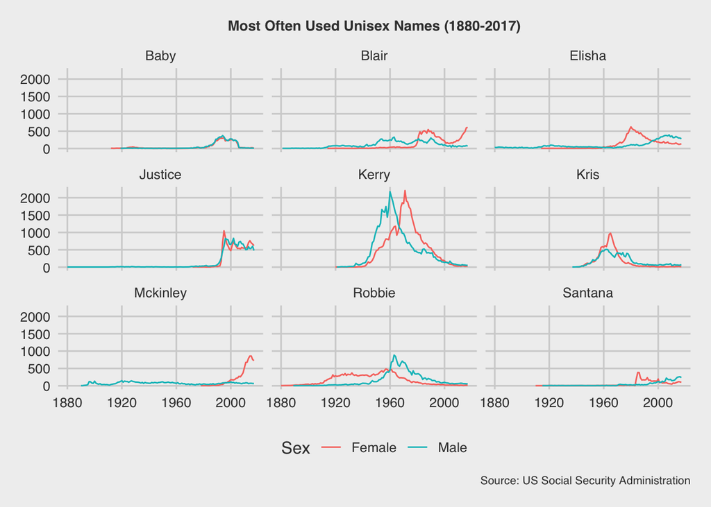

```r
babynames %>%
  filter(name %in% unisex$name & name != "Unknown") %>%
  group_by(year, name, sex) %>%
  summarize(total = sum(n)) %>%
  ungroup() %>%
  ggplot(aes(x = year, y = total))+
  geom_line(aes(group = sex, col = sex))+
  scale_y_continuous("Count")+
  facet_wrap(~name)+
  scale_color_discrete("Sex", labels = c("Female", "Male"))+
  labs(title = "Most Often Used Unisex Names (1880-2017)",
       caption = "Source: US Social Security Administration")+
  theme_fivethirtyeight()+
  theme(plot.title = element_text(size = 10, face = "bold", hjust = 0.5),
        plot.caption = element_text(size = 8))
```

3. Identify one particular pattern in the data. For example:
   - religious names are less/more common over time
   - the top 5 names capture a different portion of all names at different points in time
   - there are more “unique” names now
   - certain names became popular after historical events / figures etc.
   - some old names are making a revival after a certain time period (say a generation?)

Then try to capture this one pattern in a graphical display that highlights this one point.

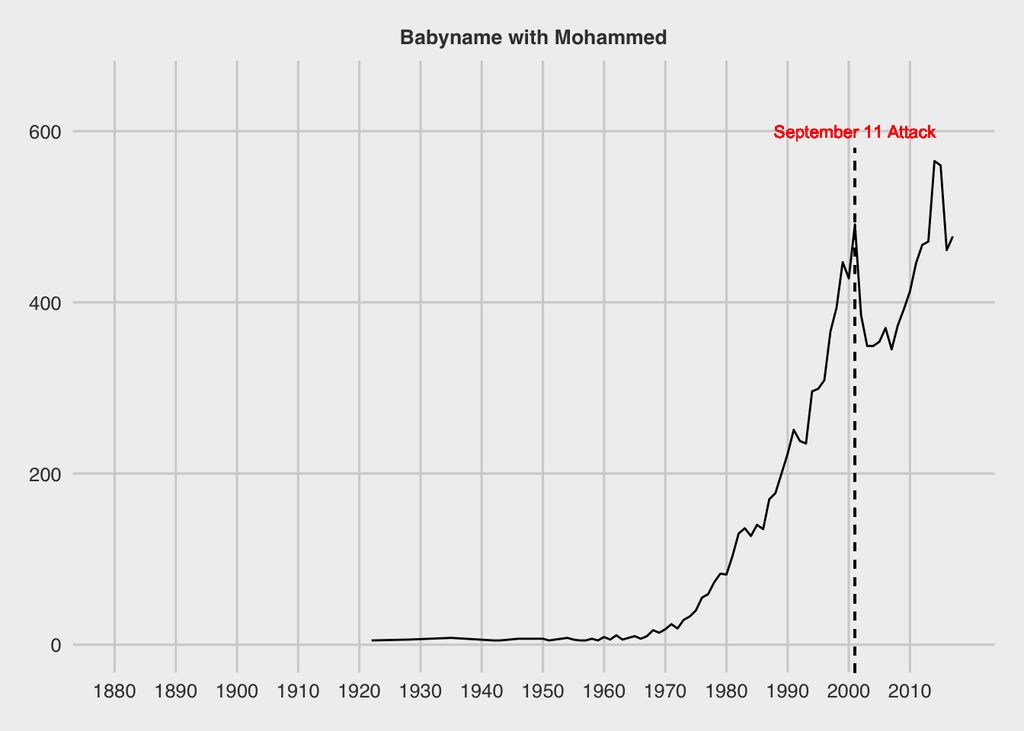

```r
babynames %>%
  filter(name == "Mohammed") %>%
  ggplot(aes(x = year, y = n))+
  geom_line()+
  scale_y_continuous("Count", limits = c(0, 650))+
  scale_x_continuous("Year", limits = c(1880, 2017), breaks = seq(1880, 2017, by = 10))+
  geom_segment(aes(x = 2001, y = -Inf, xend = 2001, yend = 580), linetype = "dashed")+
  geom_text(label = "September 11 Attack", x = 2001, y = 600, color = "red", size = 3)+
  labs(title = "Babyname with Mohammed")+
  theme_fivethirtyeight()+
  theme(plot.title = element_text(size = 10, face = "bold", hjust = 0.5))
```

## Some Intersting Posts

“Guessing the year you were born from aby names using R”, by Jacqueline Nolis. [Read](https://towardsdatascience.com/guessing-the-year-you-were-born-from-baby-names-using-r-17c8cbb8d0a5). The author creates a simply shiny apps to make data interactive.

“The Most Common Unisex Names in America: Is Yours One of Them?”, by Andrew Flowers. [Read](https://fivethirtyeight.com/features/there-are-922-unisex-names-in-america-is-yours-one-of-them/). This post is quite similar with what I did here.